# lab6

Apolonia Bokszycka

4 kwietnia 2020

Zad.1.  
Wczytuję dane i skaluję.

Zad. 2. (przykładowe)

```r
x <- c(0.42, 0.03, -0.90, 0.15, -1.25, -0.15, -0.01, 0.73, 0.90, -0.82, -0.69)
distances <- apply(wine[,-1], 1, function(y) sqrt(sum((x-y)^2)))
k <- 3
najblizsze_wiersze <- order(distances)[1:k]
najblizsze_klasy <- wine[najblizsze_wiersze, 1]
czestosc_klas <- table(najblizsze_klasy)
czestosc_klas
```

```
## najblizsze_klasy
## 3 4 5 6 7 8 9
## 1 1 1 0 0 0 0
```

```r
najczestsza_klasa <- which.max(czestosc_klas)
najczestsza_klasa
```

```
## 3
## 1
```

```r
najczestsza_klasa <- levels(wine$Quality)[najczestsza_klasa]
```

Zad.3.

```r
#błąd testowy, błąd treningowy
library(ggplot2)
library(class)
indeksy_testowe <- sample(1:nrow(wine), 480, replace=F)
zbior_testowy <- wine[indeksy_testowe, ]
zbior_treningowy <- wine[-indeksy_testowe, ]
wynik <- knn(zbior_treningowy[,-1], zbior_testowy[,-1], zbior_treningowy[,1], k=3)
mean(wynik==zbior_testowy[,1])
```

```
## [1] 0.45
```

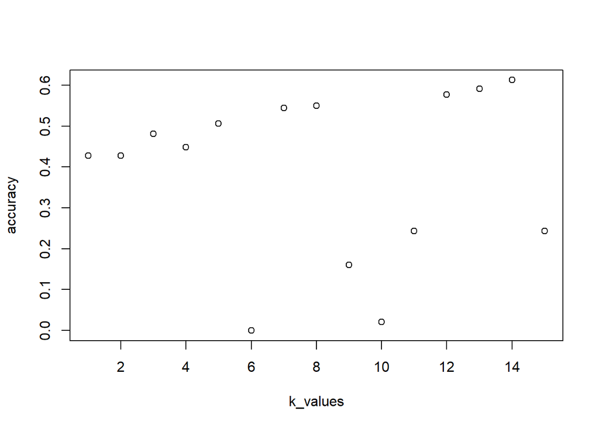

```r
accuracy <- vector()
k_values <- vector()
for (i in 1:15){
  wynik <- knn(zbior_treningowy[,-1], zbior_testowy[,-1], zbior_treningowy[,1], k=i)
  accuracy[i] <- mean(wynik==zbior_testowy[i,1])
  k_values[i] <- i
}

plot(k_values, accuracy)
```

[figure not shown]

```r
dane_ka<- data.frame(k_values=k_values, accuracy=accuracy)
ggplot(data=dane_ka,aes(x=k_values, y=accuracy)) + theme_minimal()
```

Czy jest jakiś sposób żeby nie korzystać z pętli w tym zadaniu?  
Nie wiem dlaczego nie działa mi ggplot?

zad.4. Korzystam z:  
presision = TP/(TP+FP) // im więcej klas fałszywie zaklasyfikowanych jako dobrych, tym mniejsze presision  
recall = TP/(TP+FN) // im więcej klas fałszywie zaklasyfikowanych jako złych, tym mniejsze recall

p_a = 99/(99+0) = 1  
r_a = 99/(99+1) = 0.99  
p_b = 1/(1+0) = 1  
r_b = 1/(1+99) = 0.01

Zad.5. Wyniki dla k=3. Macierz konfuzji:

```
##      [,1] [,2] [,3] [,4] [,5] [,6] [,7]
## [1,]    0    1    1    1    0    0    0
## [2,]    0    2   10    3    1    0    0
## [3,]    1    7   62   64   15    2    0
## [4,]    1    1   43  113   35    8    0
## [5,]    0    1    9   35   36    5    0
## [6,]    0    0    1   11    5    6    0
## [7,]    0    0    0    0    0    0    0
```

Tabela z wartościami “presision” oraz “recall” dla poszczególnych klas (od 3 do 9) przy k=3:

```
##   presision    recall
## 3 0.0000000 0.0000000
## 4 0.1250000 0.1666667
## 5 0.4105960 0.4920635
## 6 0.5621891 0.4977974
## 7 0.4186047 0.3913043
## 8 0.2608696 0.2857143
## 9       NaN       NaN
```

Wyniki dla k=8. Macierz konfuzji:

```
##      [,1] [,2] [,3] [,4] [,5] [,6] [,7]
## [1,]    0    1    2    0    0    0    0
## [2,]    0    0   12    1    3    0    0
## [3,]    0    2   60   72   15    2    0
## [4,]    0    0   43  129   25    4    0
## [5,]    0    0    6   50   27    3    0
## [6,]    0    0    4   11    6    2    0
## [7,]    0    0    0    0    0    0    0
```

Tabela z wartościami “presision” oraz “recall” dla poszczególnych klas (od 3 do 9) przy k=8:

```
##    presision    recall
## 3 0.00000000       NaN
## 4 0.00000000 0.0000000
## 5 0.39735099 0.4724409
## 6 0.64179104 0.4904943
## 7 0.31395349 0.3552632
## 8 0.08695652 0.1818182
## 9        NaN       NaN
```

Wyniki dla k=15. Macierz konfuzji:

```
##      [,1] [,2] [,3] [,4] [,5] [,6] [,7]
## [1,]    0    2    0    1    0    0    0
## [2,]    0    2   10    3    1    0    0
## [3,]    0    6   64   61   19    1    0
## [4,]    0    0   52  112   30    7    0
## [5,]    0    2    6   36   38    4    0
## [6,]    0    1    1   10    6    5    0
## [7,]    0    0    0    0    0    0    0
```

Tabela z wartościami “presision” oraz “recall” dla poszczególnych klas (od 3 do 9) przy k=15:

```
##   presision    recall
## 3 0.0000000       NaN
## 4 0.1250000 0.1538462
## 5 0.4238411 0.4812030
## 6 0.5572139 0.5022422
## 7 0.4418605 0.4042553
## 8 0.2173913 0.2941176
## 9       NaN       NaN
```

Jeśli wino ma jakość 5, to jakie jest prawdopodobieństwo, że klasyfikator zaklasyfikuje je poprawnie?  
około 50%

Czy klasyfikator lepiej klasyfikuje wina o rzadkich, czy o powszechnych jakościach? Która jakość wina jest poprawnie klasyfikowana najczęściej? Która klasa zwrócona przez klasyfikator jest najbardziej wiarygodna?  
Klasyfikator lepiej klasyfikuje wina o powszechnych jakościach.  
Klasa 6 jest poprawnie klasyfikowana najczęściej.  
Klasa 6 jest również najbardziej wiarygodna.

Jaka jest szansa, że w rzeczywistości wino jest lepsze, niż twierdzi klasyfikator? A jaka, że gorsze?

Niestety nie wiem jak odpowiedzieć na ostatnie pytanie.